# fitbitdata_analysis

Aparna

December 11, 2016

## Using devices such as Jawbone Up, Nike FuelBand, and Fitbit it is now possible to collect a large amount of data about personal activity relatively inexpensively. These type of devices are part of the quantified self movement - a group of enthusiasts who take measurements about themselves regularly to improve their health, to find patterns in their behavior, or because they are tech geeks. One thing that people regularly do is quantify how much of a particular activity they do, but they rarely quantify how well they do it. In this project, your goal will be to use data from accelerometers on the belt, forearm, arm, and dumbell of 6 participants. They were asked to perform barbell lifts correctly and incorrectly in 5 different ways.The goal is to predict the manner in which they did the exercise. This is the “classe” variable in the training set

# Reading the dataset

```r
urltrain <- "https://d396qusza40orc.cloudfront.net/predmachlearn/pml-training.csv"
urltest <- "https://d396qusza40orc.cloudfront.net/predmachlearn/pml-testing.csv"
download.file(urltrain, destfile = "D:/OLD DATA/d/R learning/machineL/training.csv")
download.file(urltest, destfile = "D:/OLD DATA/d/R learning/machineL/testing.csv")
# Using the commands:
training = read.csv("D:/OLD DATA/d/R learning/machineL/training.csv")
testing <- read.csv("D:/OLD DATA/d/R learning/machineL/testing.csv")
```

# Understanding the dataset

```r
dim(training)
```

```
## [1] 19622   160
```

```r
str(training)
```

```
## 'data.frame':    19622 obs. of  160 variables:
##  $ X                       : int  1 2 3 4 5 6 7 8 9 10 ...
##  $ user_name               : Factor w/ 6 levels "adelmo","carlitos",..: 2 2 2 2 2 2 2 2 2 2 ...
##  $ raw_timestamp_part_1    : int  1323084231 1323084231 1323084231 1323084232 1323084232 1323084232 1323084232 1323084232 1323084232 1323084232 ...
##  $ raw_timestamp_part_2    : int  788290 808298 820366 120339 196328 304277 368296 440390 484323 484434 ...
##  $ cvtd_timestamp          : Factor w/ 20 levels "02/12/2011 13:32",..: 9 9 9 9 9 9 9 9 9 9 ...
##  $ new_window              : Factor w/ 2 levels "no","yes": 1 1 1 1 1 1 1 1 1 1 ...
##  $ num_window              : int  11 11 11 12 12 12 12 12 12 12 ...
##  $ roll_belt               : num  1.41 1.41 1.42 1.48 1.48 1.45 1.42 1.42 1.43 1.45 ...
##  $ pitch_belt              : num  8.07 8.07 8.07 8.05 8.07 8.06 8.09 8.13 8.16 8.17 ...
##  $ yaw_belt                : num  -94.4 -94.4 -94.4 -94.4 -94.4 -94.4 -94.4 -94.4 -94.4 -94.4 ...
##  $ total_accel_belt        : int  3 3 3 3 3 3 3 3 3 3 ...
##  $ kurtosis_roll_belt      : Factor w/ 397 levels "","-0.016850",..: 1 1 1 1 1 1 1 1 1 1 ...
##  $ kurtosis_picth_belt     : Factor w/ 317 levels "","-0.021887",..: 1 1 1 1 1 1 1 1 1 1 ...
##  $ kurtosis_yaw_belt       : Factor w/ 2 levels "","#DIV/0!": 1 1 1 1 1 1 1 1 1 1 ...
```

[output cut: 86 more lines]

```r
levels(training$classe)
```

```
## [1] "A" "B" "C" "D" "E"
```

## Load all libraries

```r
library(caret)
library(kernlab)
library(ISLR)
library(Hmisc)
```

```r
library(rpart)
library(rpart.plot)
library(AppliedPredictiveModeling)
library(e1071)
library(randomForest)
library(gbm)
```

# Cleaning the data for variables without variance and removing variables with more than 60% NAs

```r
nzv <- nearZeroVar(training)
training <- training[, -nzv]
dim(training)
```

```
## [1] 19622   100
```

```r
training_1 <- training
for(i in 1:length(training))
        if( sum( is.na( training[, i] ) ) /nrow(training) >= .6 )
        for(j in 1:length(training_1))
            if( length( grep(names(training[i]), names(training_1)[j]) ) ==1)
                training_1 <- training_1[ , -j]

dim(training_1)
```

```
## [1] 19622    59
```

```r
training <- training_1
```

# Variables related with data acquisition (like: id, timestamps, individuals’ names, etc.) are not suitable to be used in prediction and are removed

```r
training <- training[, -(1:6)]
training$classe = factor(training$classe)
```

# Within training, create a training and testing dataset for building the model and validating it

```r
inTrain = createDataPartition(training$classe, p = 3/4)[[1]]
train = training[ inTrain,]
test = training[-inTrain,]
```

# Train 2 different models and check the accuracy on out of sample dataset

```r
tc <- trainControl(method = "cv", number = 7, verboseIter=FALSE , preProcOptions="pca", allowParallel=TRUE)
mod1 <- train(classe ~ ., data=train, method="rf", trControl= tc)
mod2<- train(classe ~ ., data=train, method ="svmRadial", trControl= tc)

pred1 <- predict(mod1, test)
pred2 <- predict(mod2, test)

confusionMatrix(pred1, test$classe)
```

```
## Confusion Matrix and Statistics
##
##           Reference
## Prediction    A    B    C    D    E
##          A 1393    2    0    0    0
##          B    0  945    2    0    0
##          C    1    2  849   11    0
##          D    0    0    4  793    1
##          E    1    0    0    0  900
##
## Overall Statistics
##
##                Accuracy : 0.9951
##                  95% CI : (0.9927, 0.9969)
##     No Information Rate : 0.2845
##     P-Value [Acc > NIR] : < 2.2e-16
##
##                   Kappa : 0.9938
##  Mcnemar's Test P-Value : NA
##
## Statistics by Class:
##
##                      Class: A Class: B Class: C Class: D Class: E
## Sensitivity            0.9986   0.9958   0.9930   0.9863   0.9989
## Specificity            0.9994   0.9995   0.9965   0.9988   0.9998
## Pos Pred Value         0.9986   0.9979   0.9838   0.9937   0.9989
## Neg Pred Value         0.9994   0.9990   0.9985   0.9973   0.9998
## Prevalence             0.2845   0.1935   0.1743   0.1639   0.1837
## Detection Rate         0.2841   0.1927   0.1731   0.1617   0.1835
## Detection Prevalence   0.2845   0.1931   0.1760   0.1627   0.1837
## Balanced Accuracy      0.9990   0.9976   0.9948   0.9925   0.9993
```

```r
confusionMatrix(pred2, test$classe)
```

```
## Confusion Matrix and Statistics
##
##           Reference
## Prediction    A    B    C    D    E
##          A 1387   82    2    5    0
##          B    2  835   41    1   12
##          C    4   32  789   85   24
##          D    0    0   14  711   24
##          E    2    0    9    2  841
##
## Overall Statistics
##
##                Accuracy : 0.9305
##                  95% CI : (0.923, 0.9374)
##     No Information Rate : 0.2845
##     P-Value [Acc > NIR] : < 2.2e-16
##
##                   Kappa : 0.9119
##  Mcnemar's Test P-Value : < 2.2e-16
##
## Statistics by Class:
##
##                      Class: A Class: B Class: C Class: D Class: E
## Sensitivity            0.9943   0.8799   0.9228   0.8843   0.9334
## Specificity            0.9746   0.9858   0.9642   0.9907   0.9968
## Pos Pred Value         0.9397   0.9371   0.8448   0.9493   0.9848
## Neg Pred Value         0.9977   0.9716   0.9834   0.9776   0.9852
## Prevalence             0.2845   0.1935   0.1743   0.1639   0.1837
## Detection Rate         0.2828   0.1703   0.1609   0.1450   0.1715
## Detection Prevalence   0.3010   0.1817   0.1905   0.1527   0.1741
## Balanced Accuracy      0.9845   0.9329   0.9435   0.9375   0.9651
```

## Random Forest gives a better model.

```r
mod1
```

```
## Random Forest
##
## 14718 samples
##    52 predictor
##     5 classes: 'A', 'B', 'C', 'D', 'E'
##
## No pre-processing
## Resampling: Cross-Validated (7 fold)
## Summary of sample sizes: 12617, 12614, 12616, 12615, 12616, 12614, ...
## Resampling results across tuning parameters:
##
##   mtry  Accuracy   Kappa
##    2    0.9911670  0.9888258
##   27    0.9918461  0.9896846
##   52    0.9857302  0.9819469
##
## Accuracy was used to select the optimal model using  the largest value.
## The final value used for the model was mtry = 27.
```

```r
varImp(mod1)
```

```
## rf variable importance
##
##   only 20 most important variables shown (out of 52)
##
##                      Overall
## roll_belt            100.000
## pitch_forearm         59.037
## yaw_belt              53.013
## pitch_belt            44.696
## magnet_dumbbell_z     44.475
## magnet_dumbbell_y     44.469
## roll_forearm          40.914
## accel_dumbbell_y      21.899
## accel_forearm_x       17.873
## roll_dumbbell         17.708
## magnet_dumbbell_x     16.392
## accel_dumbbell_z      14.747
## accel_belt_z          14.183
## magnet_forearm_z      13.874
## magnet_belt_z         13.865
## total_accel_dumbbell  13.607
## magnet_belt_y         11.566
## gyros_belt_z          11.434
## yaw_arm               10.974
## magnet_belt_x          9.822
```

# Including Plots

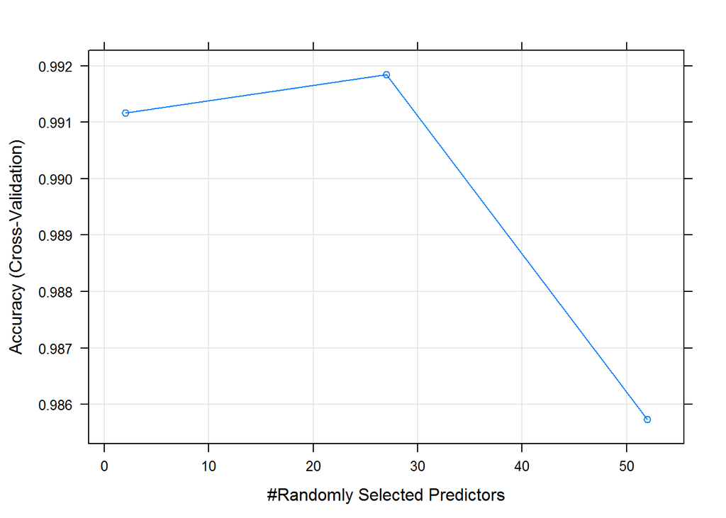

#Predicting Results on the Test Data using Random Forest since that had higher accuracy

```r
rfPredictions <- predict(mod1, newdata = testing)
rfPredictions
```

```
##  [1] B A B A A E D B A A B C B A E E A B B B
## Levels: A B C D E
```